# Lifespan variation and life expectancy in UK nations

# Introduction

This short notebook will look at how average age of death and lifespan variation have changed in UK nations oer the 20th century. The aim is to make what’s meant by the following statement clearer:

```
[Our aim is] That mortality trends improve (and inequalities narrow), such that there
is (at least) 'catch up' to the previous trends. This would involve improving the
rate of improvement back to the rapid improvement rates seen (for example) during
the 2000s and the rates of improvement in inequalities seen between the
1950s and the 1970s.
```

Let’s just look at England/Wales, and Scotland, (as Northern Ireland is complicated by the Troubles and has a smaller population).

## Measures

- Improvements
  - Median age of death
  - Life expectancy
- Inequalities
  - 80-20 interval in age of death

The 80-20 interval is the difference in years of age between the age by which 20% of deaths have occurred, and the age by which 80% of deaths have occurred. I felt this was easier to convey than (say) variance in age of death.

# Results

## Life expectancy

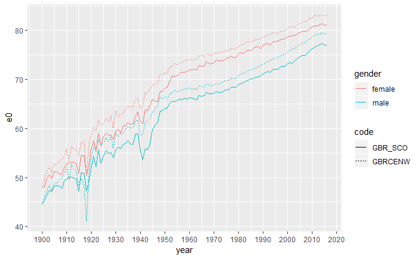

What was the average rate of improvement in e0 by decade?

## Figures

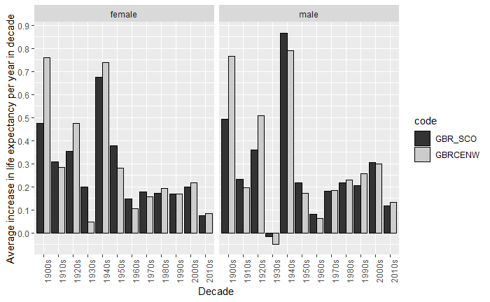

# Lifespan variation

## Figure

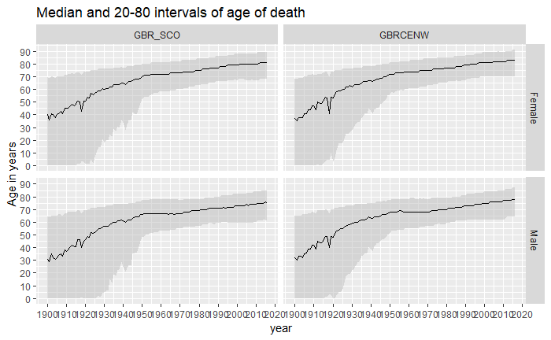

# Conclusions

We should aim for 80-20 intervals of ‘only’ around 20 years, and average annual live expectancy improvements of at least 0.15 years/year averaged over ten years.